# Statistics with R Assignment 1

Yashjit Gangopadhyay (2662062)

24/04/2020

```r
knitr::opts_knit$set(root.dir = "/Users/yash/Downloads/Assignment_01/data")
```

# Question 1

The data had already been well pre-processed. - comments are separated into individual column. - names are consistent without spaces and in most of the cases, camelCase is used. - cell formatting wasn’t used - the general data split in the 3 sheets (counts, samples, communities) is fine. - sample numbers were used as key. However the following factors could have been improved: - taxonomic data could have been separated into an individual metadata file. - more metadata files were required (except taxonomic data). - counts data could have been pre-processed to long/tidy format. - missing values were not treated nor a warning for bad data was provided. - it is better to avoid using more than one language (English and French in this case) as the medium to record data. - ‘date’ and ‘time’ columns in sample table needed formatting. - categorical variables could have been encoded.

# Question 2

Importing required libraries.

```r
library('readxl')
library('tidyverse')
```

Importing data into objects ‘counts’, ‘communities’ and ‘samples’.

```r
#setwd("/Users/yash/Downloads/Assignment_01/data")
counts = read_excel('lait_caille_data.xlsx')
samples = read_excel('lait_caille_data.xlsx', sheet = 'samples')
communities = read_excel('lait_caille_data.xlsx', sheet = 'communities')
```

# Question 3

Splitting ‘counts’ object into ‘taxonomy’ and ‘counts’ by ‘rankID’.

```r
taxonomy <- select(counts, c(taxlevel, rankID, taxon))
counts <- select(counts, -c(taxlevel, taxon) )
```

Gathering ‘counts’ into a longer form ‘counts_l’.

```r
counts_l <- gather(data = counts, key = sample, value = count, -rankID, factor_key=FALSE)
```

# Question 4

Checking if all unique values in ‘counts’ is also present in ‘samples’.

```r
check_unique <- c(counts_l$sample %>% unique() ==  samples$sample %>% unique())
if (check_unique %>% unique()== TRUE){
  print("All samples in 'counts' are present in 'samples'.")
} else {
  print("Some values are missing")
}
```

```
## [1] "All samples in 'counts' are present in 'samples'."
```

# Question 5

Create ‘counts_selected’ with ’taxonomy$taxlevel = 6 and samples$community = communities$original

```r
counts_selected <- counts_l %>%
  filter(sample %in% subset(samples, community %in% communities$original)$sample) %>%
  filter(rankID %in% subset(taxonomy, taxlevel == 6)$rankID)
```

# Question 6

Create ‘counts_selected’ by calculating fraction of counts in each sample per genus.

```r
counts_selected <- counts_selected %>% group_by(sample) %>% mutate(fraction = count/sum(count)) %>% ungroup
```

# Question 7

Create ‘counts_LAB’ with individual counts and total fractions of the desired bacterias. Create a histogram of the total fractions.

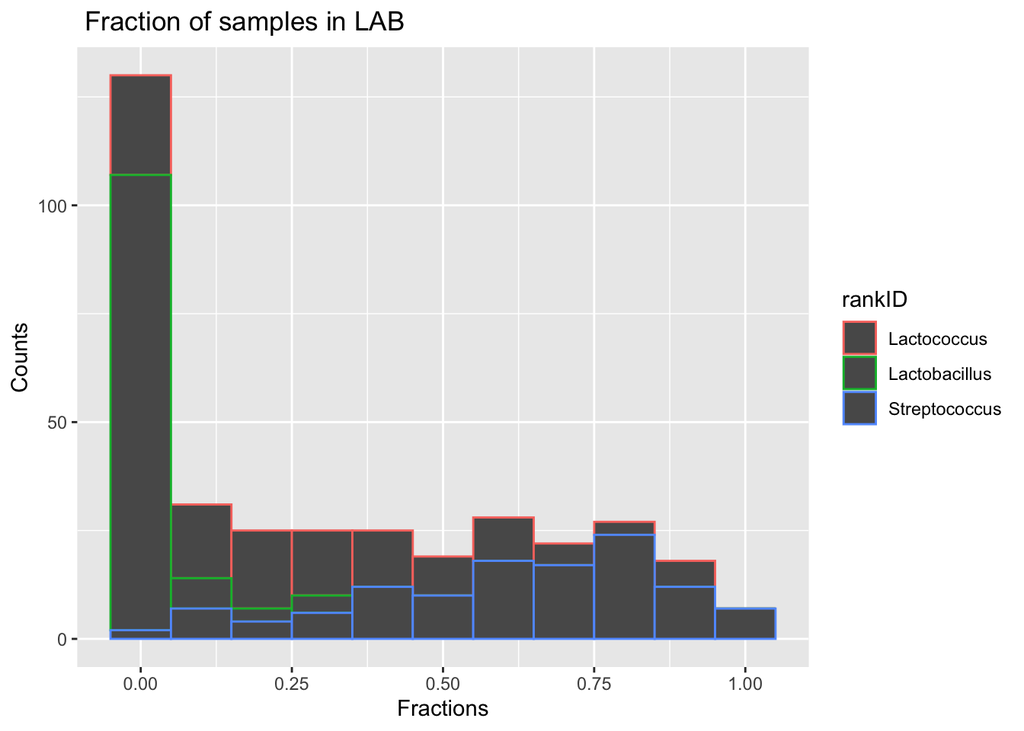

```r
LAB <-filter(taxonomy, taxon %in% c("Lactococcus", "Lactobacillus", "Streptococcus"))
counts_LAB <- filter(counts_selected, rankID %in% LAB)
counts_LAB <- counts_selected %>% filter(rankID %in% LAB$rankID)

hist_plot <- ggplot(counts_LAB, aes(x = fraction, colour = rankID))+
  geom_histogram(binwidth = 0.1) +
  labs(title=" Fraction of samples in LAB",
       x ="Fractions", y = "Counts")+
  scale_colour_discrete(labels = c("Lactococcus", "Lactobacillus", "Streptococcus"))

hist_plot
```